# BMS270 SP2019: 16S rRNA exploratory data analysis

Jordan Bisanz

2019-05-21 11:46

# 1 Background

In this tutorial, we will be carrying out exploratory data analysis of unknown microbiota samples of human origin profiled using single-ended Illumina sequenced V4 amplicons. We will be focusing on how to process raw data, generate useful metrics for comparing microbial communities and visualizing samples to try to uncover underlying biological connections between them. The samples we will be analyzing today were sequenced and made available through the NCBI Sequence Read Archive and at the completion of the tutorial, you will be able to test if your generated hypotheses are correct.

# 2 Homework before class

*Note: depending on your internet and computer speed, this may take up to half an hour. Please have this completed before class and email if you have any issues.*

## 2.1 Installing R

We will be making use of the R programming language which is commonly used across many fields for statistical analysis. To begin, please install and/or update to version of R (3.6.0) by downloading from the following [link](https://cran.cnr.berkeley.edu/). R is commonly accessed through an easy-to-use interface called R studio. This can be downloaded [here](https://www.rstudio.com/products/rstudio/download/). Microbiome-analysis software is frequently updated and is often not back-compatible so *please ensure you have the latest version of R.* You can always check your version by running the following command in R.

```r
R.Version()$version.string
```

```
## [1] "R version 3.6.0 (2019-04-26)"
```

In this tutorial, code that will you run is displayed inside grey boxes, you can either type these out, or copy and paste them into your own Rscript to run.

Make sure you have created a directory you can work in and move to this directory. In my case it will be on my desktop. Note that the location will be slightly different for UNIX and windows operating systems.

```r
# On OSX and LINUX:
dir.create("~/Desktop/BMS270_tutorial")
setwd("~/Desktop/BMS270_tutorial")

# On Windows
dir.create("C:\Users\YourUserName\Desktop")
setwd("C:\Users\YourUserName\Desktop")
```

## 2.2 Installing Libraries

We will now install the libraries we will need to run our analyses. Generally speaking, there are two ways of installing libraries depending on the repository from which they come: CRAN (comprehensive R archive network) or Bioconductor (specializes in bioinformatics). We will start by obtaining libraries from CRAN, which will include a tool to install Bioconductor libraries. CRAN libraries can be installed using the `install.packages()` function. Note, when coding in many languages including R, anything following a # is called a comment and is not actually run.

```r
install.packages("tidyverse") # this is a suite of tools for data science that greatly extend the function of R
install.packages("vegan") # useful ecology package
install.packages("ape") # useful ecology packag
install.packages("phangorn") # useful package to deal with phylogenetic trees
install.packages("BiocManager") # the installer for Bioconductor packages
install.packages("cluster") # for cluster analysis
```

When installing packages, make sure that there have not been any errors, if asked to compile, say yes. When installation has been successful, the last line usually reads that the downloaded source/binary packages are in …

Now we can install the packages we need from Bioconductor using the `BiocManager::install()` command. A quick note, you may be asked if you want to update old packages after every Bioconductor installation, it is safe to say no.

```r
BiocManager::install("dada2") # our primary tool for processing sequencing data
BiocManager::install("phyloseq") # useful microbiome-centric R package
BiocManager::install("DECIPHER") # For nucleotide alignments
BiocManager::install("Biostrings") # For handling FASTA-like files
BiocManager::install("ggtree") # For visualizing trees
BiocManager::install("phytools") # For manipulating phylogenetic trees
BiocManager::install("treeio") # For manipulating phylogenetic trees
```

Now as a last step, we can load all of these libraries to make sure they have installed properly.

```r
library(tidyverse)
library(vegan)
library(ape)
library(dada2)
library(phyloseq)
library(DECIPHER)
library(Biostrings)
library(ggtree)
library(cluster)
library(phangorn)
```

If the package has not been installed, the error message will read: `Error in library(dada2) : there is no package called ‘dada2’`.

## 2.3 Downloading Sequence Data

We need a companion database to use with dada2 which will allow us to identify the taxa found in our samples. For this purpose we will use [SILVA version 132](https://www.arb-silva.de/documentation/release-132/) which is an alternative to older commonly used databases such as Green Genes. We can download files directly in R as below using the `download.file()` function; however, certain windows users may need to manually download these files by visiting this [link](https://benjjneb.github.io/dada2/training.html).

```r
download.file(
  url="https://zenodo.org/record/1172783/files/silva_nr_v132_train_set.fa.gz?download=1",
  destfile="silva_nr_v132_train_set.fa.gz"
  )

download.file(
  url="https://zenodo.org/record/1172783/files/silva_species_assignment_v132.fa.gz?download=1",
  destfile="silva_species_assignment_v132.fa.gz"
)
```

We can now download the raw sequencing data in fastq file format which stores both the sequence information and information about the quality of the base call in a single file. Read more about it [here](https://en.wikipedia.org/wiki/FASTQ_format). Usually, a sequence center will provide a directory containing all of your sequencing reads separated on per sample basis, but some times you may need to separate the reads yourself which is called demultiplexing which is supported by a wide variety of tools. Today we will use a common format wherein every sample is represented in its own fastq file which has been compressed using gzip, a commonly used compression algorithm.

```r
download.file(
  url="https://github.com/jbisanz/BMS270_SP2019/raw/master/BMS270_SP2019_reads.tar.gz",
  destfile="BMS270_SP2019_reads.tar.gz"
  )
```

Finally we can extract this directory using the built in `untar()` function as below.

```r
untar("BMS270_SP2019_reads.tar.gz")
```

Before class it may be worth while getting some practice working with R and a suite of packages we will be using called the tidyverse. You can access a tutorial [here](https://www.datacamp.com/courses/introduction-to-the-tidyverse). It is encouraged, but not mandatory.

**You are now ready for class. I look forward to meeting you! Please do not hesitate to email if you have any problems in downloading or installing the necessary items for this tutorial.**

# 3 Processing Raw Data: FASTQ to Features

## 3.1 Setting up an Rscript

When working with R, it is always a good idea to create an R script to work in and track the commands you have run. This can be accomplished in Rstudio by selecting File > New File > R script. Save this file (ending in the .R extension) in the directory we created above on your Desktop (BMS270_tutorial). The first thing to do in your R script is to set your working directory using `setwd()` and load the libraries you will need.

```r
setwd("~/Desktop/BMS270_tutorial")

library(tidyverse)
library(vegan)
library(ape)
library(dada2)
library(phyloseq)
library(DECIPHER)
library(Biostrings)
library(ggtree)
library(cluster)
library(phangorn)
```

We can also set up some sub directories in which we can store our results:

```r
dir.create("figures")
dir.create("tables")
dir.create("outputs")
```

Finally, we can check our session using the `sessionInfo()` command which describe our environment and all the package versions we are using. This is very helpful when preparing the methods section for a manuscript!

[session information not shown]

## 3.2 FASTQ QC

The first step in analyzing high-throughput sequencing data should always be checking the quality of the reads. Sequencing data is commonly analyzed in the FASTQ format which is similar to the commonly used FASTA format with the addition of a line describing the confidence in the basecalls. FASTQ files follow the following repeating pattern of 4 lines:

```
@M01869:139:000000000-AMK49:1:1101:11347:1451 1:N:0:6
GGAACAGGAAGAACACGGCGGCGATAACCATGCGCACGCAGGTGATCCACGTGGCGGGAGCGCCGTAGTCGTTCATGAGCAGCTGGGCGCACGTGCCCG
+
--,-A-69----6C8E7+@++@++@:7EE,C,@+B7@+@+++C,,<CC,C:D,,@+++++8+>C7F++B@:DFF,B9,,:,,8B,,+:+>+@+B,3>>+
```

The @ line is called the header which denotes the unique identifier for the read. The following line contains the DNA sequence. The 3rd line usually contains just a + sign; however, sometimes the header is repeated. The 4th line encodes the quality information using a scheme wherein individual symbols represent a score out of ~42 which denotes the probability of an error. Most sequencing data generated after ~2013 uses a scoring system called phred33. Find more information on interpreting these scores [here](http://drive5.com/usearch/manual/quality_score.html).

Because we can’t easily read these quality scores, it helps to plot the quality. We can use a function called `plotQuality()` to do this. We will sample 3 random fastq files from our data set to analyze as below.

*Note: the pipe operator (%>%) sends the output of the command to the next line and is common feature in scripting languages. Usually you do not need to do anything special, but for some functions, we must explicitely tell it to expect the data from the previous line by using the `.` as an argument. This is a staple of the tidyverse; however, you could save the individual outputs of each line and manually type it in to the next line. You can highlight a portion of the series of chained command to see the intermediate output for the purposes of problem solving. In this case we can split long functions over multiple lines to make it easier to read and so we can se the individual steps involved.*

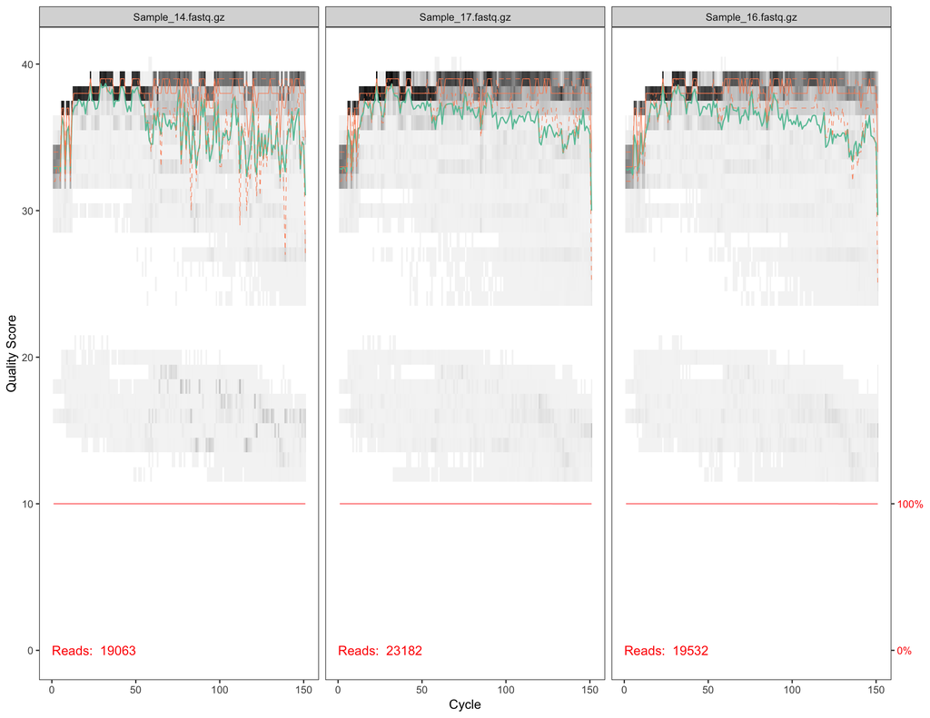

```r
list.files("reads", full.names = TRUE) %>%
  sample(3) %>%
  plotQualityProfile()
```

**QUESTION: What do the dashed orange lines represent in the above plot?**

These sequences look good and a slight dip in sequencing quality can be expected across the read. Usually, sequence quality issues will be consistent across all samples. Although in some cases, such as with heavy primer/adapter dimer contamination, some samples can be more affected than others. For an example of bad sequencing, see [here](https://www.biostars.org/p/354039/).

Next we will build a table containing the names of all of our reads. There are multiple types of table-like data structures in R, most commonly: data.frames and matrices, although tibbles (part of the tidyverse) and data.tables (from the data.table) package are also quite common. Each has their strengths and weaknesses. The data.table is the most computationally efficient method; however, it is not as user friendly as the tibble. Because our dataset is quite small, we will be using tibbles for most of this tutorial. We will also create a new set of file names to put the result of quality-filtered reads into by pasting the text “filtered_” in front of the current file location.

```r
metadata<-
  list.files("reads", full.names=TRUE) %>%
  tibble(FASTQ=.) %>%
  mutate(Filtered_FASTQ=paste0("filtered_", FASTQ)) # mutate creates a new column in your table.

metadata # look at the data, note how the data is nicely displayed in your window, this property is unique to tibbles and data.tables.
```

```
## # A tibble: 27 x 2
##    FASTQ                    Filtered_FASTQ
##    <chr>                    <chr>
##  1 reads/Sample_1.fastq.gz  filtered_reads/Sample_1.fastq.gz
##  2 reads/Sample_10.fastq.gz filtered_reads/Sample_10.fastq.gz
##  3 reads/Sample_11.fastq.gz filtered_reads/Sample_11.fastq.gz
##  4 reads/Sample_12.fastq.gz filtered_reads/Sample_12.fastq.gz
##  5 reads/Sample_13.fastq.gz filtered_reads/Sample_13.fastq.gz
##  6 reads/Sample_14.fastq.gz filtered_reads/Sample_14.fastq.gz
##  7 reads/Sample_15.fastq.gz filtered_reads/Sample_15.fastq.gz
##  8 reads/Sample_16.fastq.gz filtered_reads/Sample_16.fastq.gz
##  9 reads/Sample_17.fastq.gz filtered_reads/Sample_17.fastq.gz
## 10 reads/Sample_18.fastq.gz filtered_reads/Sample_18.fastq.gz
## # … with 17 more rows
```

Now we can run a filtering command to remove low-quality reads and trim off any bad portions. Our sequencing data looks quite good, but filtering is still necessary to catch the outliers.

*Note: When dealing with tibbles, data.frames, and data.tables, we can extract any given column by name using the object$Column_name notation.*

```r
dir.create("filtered_reads")
filterlog<-
  filterAndTrim(
    fwd=metadata$FASTQ,
    filt=metadata$Filtered_FASTQ,
    maxN=0, # Do not allow N bases, ie those that can't be determined
    maxEE=2, #allow no more than 2 expected errors in a read, this is calculated based on base quality across the reads
    truncQ=2, #trim the read at a score of 2 or less.
    truncLen=140, #trim reads back to be 140bp
    minLen=140, # remove reads that are less than 140bp after trimming
    rm.phix=TRUE, #remove phiX DNA
    multithread=TRUE #!!!!!!!!!SET TO FALSE ON WINDOWS!!!!!!!!!
  )
```

**QUESTION: What is phiX and why might we remove it?**

The results of the filtering have been sent to variable we called filterlog. We can now examine this to see how many reads were lost.

*A quick note, you will see in some places we have used the `as.data.frame()` function combined with `row_names_to_column()` and `as_tibble()`. This is being done to convert a matrix to a tibble which is not strictly necessary but makes for easier manipulation using the tidyverse.*

```r
readloss<-
  filterlog %>%
  as.data.frame() %>%
  rownames_to_column("SampleID") %>%
  as_tibble() %>%
  mutate(Percent_Reads_Lost=(1-(reads.out/reads.in))*100)

summary(readloss$Percent_Reads_Lost)
```

```
##    Min. 1st Qu.  Median    Mean 3rd Qu.    Max.
##   1.038   1.357   1.624   1.635   1.877   3.326
```

As you can see in the above summary, we lost between 1.038 and 3.326% of reads which is fairly negligible. Generally, it is preferable to have less high quality data, then more junk data. Like many aspects of data science Garbage In = Garbage Out.

## 3.3 Denosing Sequencing Data

Amplicon sequencing tends to be very noisy. To deal with this, operational taxonomic units (OTUs) have been heavily used for analysis. In this type of analysis, sequences are clustered based on a % identity threshold, often 97%. This has the advantage of negating sequencing errors but causes a lack of resolution. 97% is generally based on the notion that the 16S rRNA of two members of the same species is >=97%; however, this is based on the whole 16S rRNA gene, and not a small fragment as we are commonly analyzing so this logic is not entirely sound.

As a more modern approach, denoising is commonly used to identify sequencing errors and correct them. As for how it works, a simple explanation is that errors are relatively rare and as such can be identified when the error is substitution from a more abundant sequence. For a more complete explanation and alternate approaches see the manuscripts describing Dada2, or any of the other popular denoising algorithms available:

- dada2 https://www.nature.com/articles/nmeth.3869
- deblur https://msystems.asm.org/content/2/2/e00191-16
- unoise https://www.biorxiv.org/content/10.1101/081257v1
- Comparison of all three https://peerj.com/articles/5364/

```r
error_profiles<-learnErrors(metadata$Filtered_FASTQ, multithread=TRUE) # Remember to set multithread=FALSE on windows
```

```
## 81579120 total bases in 582708 reads from 27 samples will be used for learning the error rates.
```

A quick note, we are using a relatively small number of reads to make it feasible to run this tutorial on a laptop computer, but generally an entire sequencing run would be processed with 10-20 million reads or more which may provide a more accurate error estimation. Now that we have learned the error rates, we can denoise our sequencing data.

```r
denoised<-dada(metadata$Filtered_FASTQ, err=error_profiles, multithread = TRUE)
```

```
## Sample 1 - 10028 reads in 2373 unique sequences.
## Sample 2 - 14601 reads in 3958 unique sequences.
## Sample 3 - 6545 reads in 2064 unique sequences.
## Sample 4 - 44886 reads in 10888 unique sequences.
## Sample 5 - 14831 reads in 3175 unique sequences.
## Sample 6 - 18807 reads in 3215 unique sequences.
## Sample 7 - 14485 reads in 2937 unique sequences.
## Sample 8 - 19109 reads in 5470 unique sequences.
## Sample 9 - 22910 reads in 5920 unique sequences.
## Sample 10 - 26476 reads in 7126 unique sequences.
## Sample 11 - 19881 reads in 5444 unique sequences.
## Sample 12 - 21327 reads in 6915 unique sequences.
## Sample 13 - 17373 reads in 4462 unique sequences.
## Sample 14 - 17669 reads in 5085 unique sequences.
## Sample 15 - 16716 reads in 5581 unique sequences.
## Sample 16 - 33186 reads in 7767 unique sequences.
## Sample 17 - 17698 reads in 3538 unique sequences.
## Sample 18 - 15575 reads in 2995 unique sequences.
## Sample 19 - 35185 reads in 8634 unique sequences.
## Sample 20 - 17850 reads in 7236 unique sequences.
## Sample 21 - 22507 reads in 10806 unique sequences.
## Sample 22 - 13145 reads in 2679 unique sequences.
## Sample 23 - 60818 reads in 11893 unique sequences.
## Sample 24 - 28691 reads in 14985 unique sequences.
## Sample 25 - 20049 reads in 5383 unique sequences.
## Sample 26 - 7180 reads in 7092 unique sequences.
## Sample 27 - 25180 reads in 5948 unique sequences.
```

Now that we have denoised our sequencing data, we can calculate the number of unique sequences, which we will call **Sequence Variants (SVs)**, and put them into a table.

```r
SVraw<-makeSequenceTable(denoised)
```

In this table, each sample represents is a row, and each sequence is a column. We can view a small part of the table using the following scheme: `table[r,c]`. When accessing data from a table-like object, r will give the row number(s) to extract and c the column(s). If we want the 1st to 3rd rows and columns, we can use 1:3. To see the total number of reads in the table, we can simply use the `sum()` command.

```r
SVraw[1:3,1:3]
```

```
##                    TACGTAGGTCCCGAGCGTTGTCCGGATTTATTGGGCGTAAAGCGAGCGCAGGCGGTTAGATAAGTCTGAAGTTAAAGGCTGTGGCTTAACCATAGTACGCTTTGGAAACTGTTTAACTTGAGTGCAAGAGGGGAGAGTGG
## Sample_1.fastq.gz                                                                                                                                             0
## Sample_10.fastq.gz                                                                                                                                            0
## Sample_11.fastq.gz                                                                                                                                         1491
##                    TACGTAGGTGGCAAGCGTTGTCCGGATTTATTGGGCGTAAAGCGAGTGCAGGCGGCTCGATAAGTCTGATGTGAAAGCCTTCGGCTCAACCGGAGAATTGCATCAGAAACTGTCGAGCTTGAGTACAGAAGAGGAGAGTG
## Sample_1.fastq.gz                                                                                                                                            13
## Sample_10.fastq.gz                                                                                                                                           19
## Sample_11.fastq.gz                                                                                                                                            0
##                    TACGTAGGTGGCAAGCGTTGTCCGGATTTATTGGGCGTAAAGCGAGTGCAGGCGGTTCGATAAGTCTGATGTGAAAGCCTTCGGCTCAACCGGAGAATTGCATCAGAAACTGTCGAGCTTGAGTACAGAAGAGGAGAGTG
## Sample_1.fastq.gz                                                                                                                                             0
## Sample_10.fastq.gz                                                                                                                                            0
## Sample_11.fastq.gz                                                                                                                                            0
```

```r
sum(SVraw)
```

```
## [1] 555111
```

**QUESTION: Is half a million a lot of reads in 2019 and is this number important? How many might you expect if you were to send samples for sequencing now?**

## 3.4 Removing Sequencing Artifacts

When dealing with amplicon data, it is incredibly important to remove chimeric reads. These sequences are generated through a number of mechanisms but result in a read that is derived from multiple original pieces of template DNA. Certain protocols for generating 16S rRNA amplicons, including the methods used to generate this data, are highly prone to chimera formation. For more information on how to prevent their formation, see the manuscript by [Gohl et al. 2016](https://www.nature.com/articles/nbt.3601).

```r
SVnochim<-removeBimeraDenovo(SVraw, method="pooled", verbose=TRUE, multithread=TRUE)
```

**QUESTION: What percentage of our reads were chimeric? Is this high or low? How could it be improved?**

One final approach to remove artifacts is by removing low abundance and/or sporadic features. Generally, this would be done later in the analysis so as to not influence calculations of diversity, but since we need to have a light computational footprint for our tutorial, we will remove them now. We will require that a SV has to be observed in at least 2 samples.

```r
SVbinary<-SVnochim # create a temporary intermediate table
SVbinary[SVbinary>0]=1 # convert to a binary representation
SVbinary<-colSums(SVbinary) # find the number of samples the SV is observed in

SVs_to_keep<-
  tibble(SV=names(SVbinary), Observed=SVbinary) %>%
  filter(Observed>=2) %>%
  pull(SV)

length(SVs_to_keep)
```

```
## [1] 511
```

```r
SVtable<-SVnochim[,SVs_to_keep] # we can keep only the columns(SVs) we want based on name
```

**QUESTION: How many SVs did we remove? What percentage of reads belonged to them?**

## 3.5 Assigning Taxonomy

If we look at our SVs now, they are merely DNA sequences which tends to not be very helpful. To identify which organism they belong to, we can run any number of taxonomic assignment tools. In this case we will use the built in functions of Dada2 which assigns species level taxonomy based on perfect hits to reference sequences. We will be using the [SILVA 132](https://www.arb-silva.de/documentation/release-132/) database to assign taxonomy which is one of the largest and most common databases currently available.

```r
taxonomy_raw<-assignTaxonomy(SVtable, "silva_nr_v132_train_set.fa.gz", multithread = TRUE, verbose = TRUE) # set multithread=FALSE on windows
```

```
## Finished processing reference fasta.
```

```r
taxonomy_raw<-addSpecies(taxonomy_raw, "silva_species_assignment_v132.fa.gz", allowMultiple = TRUE, verbose=TRUE) # set multithread=FALSE on windows
```

```
## 220 out of 511 were assigned to the species level.
## Of which 199 had genera consistent with the input table.
```

```r
taxonomy<-
  taxonomy_raw %>%
  as.data.frame() %>%
  rownames_to_column("Sequence") %>%
  as_tibble()

taxonomy
```

```
## # A tibble: 511 x 8
##    Sequence       Kingdom  Phylum  Class  Order  Family  Genus Species
##    <chr>          <fct>    <fct>   <fct>  <fct>  <fct>   <fct> <fct>
##  1 TACGTAGGTCCCG… Bacteria Firmic… Bacil… Lacto… Strept… Stre… anginosus/c…
##  2 TACGTAGGTGGCA… Bacteria Firmic… Bacil… Lacto… Lactob… Lact… iners
##  3 TACGTAGGTGGCA… Bacteria Firmic… Bacil… Lacto… Lactob… Lact… <NA>
##  4 TACGGAGGGTGCG… Bacteria Proteo… Gamma… Paste… Pasteu… Haem… influenzae/…
##  5 TACGGAAGGTCCG… Bacteria Bacter… Bacte… Bacte… Prevot… Prev… copri
##  6 TACGTAGGGCGCA… Bacteria Actino… Actin… Bifid… Bifido… Gard… vaginalis
##  7 TACGTAGGTGGCA… Bacteria Firmic… Negat… Selen… Veillo… Veil… atypica/dis…
##  8 TACGGAAGGTCCG… Bacteria Bacter… Bacte… Bacte… Prevot… Prev… <NA>
##  9 TACGTAGGTGGCA… Bacteria Firmic… Negat… Selen… Veillo… Mega… <NA>
## 10 TACGGAGGGTGCA… Bacteria Proteo… Gamma… Aerom… Succin… Succ… <NA>
## # … with 501 more rows
```

**QUESTION: Why do some SVs not have a species assignment, and why do some have multiple?**

**QUESTION: Would you expect species assignment to vary across microbiotas and environments?**

To make our dataset easier to read, we can now replace the SV sequences, with an easier to read number. In this case we will use the format SV_#.

```r
taxonomy<-
  taxonomy %>%
  as_tibble() %>%
  mutate(SV=paste0("SV_", 1:nrow(.))) %>%
  select(SV, everything())

taxonomy
```

```
## # A tibble: 511 x 9
##    SV    Sequence     Kingdom  Phylum  Class  Order Family Genus Species
##    <chr> <chr>        <fct>    <fct>   <fct>  <fct> <fct>  <fct> <fct>
##  1 SV_1  TACGTAGGTCC… Bacteria Firmic… Bacil… Lact… Strep… Stre… anginosus…
##  2 SV_2  TACGTAGGTGG… Bacteria Firmic… Bacil… Lact… Lacto… Lact… iners
##  3 SV_3  TACGTAGGTGG… Bacteria Firmic… Bacil… Lact… Lacto… Lact… <NA>
##  4 SV_4  TACGGAGGGTG… Bacteria Proteo… Gamma… Past… Paste… Haem… influenza…
##  5 SV_5  TACGGAAGGTC… Bacteria Bacter… Bacte… Bact… Prevo… Prev… copri
##  6 SV_6  TACGTAGGGCG… Bacteria Actino… Actin… Bifi… Bifid… Gard… vaginalis
##  7 SV_7  TACGTAGGTGG… Bacteria Firmic… Negat… Sele… Veill… Veil… atypica/d…
##  8 SV_8  TACGGAAGGTC… Bacteria Bacter… Bacte… Bact… Prevo… Prev… <NA>
##  9 SV_9  TACGTAGGTGG… Bacteria Firmic… Negat… Sele… Veill… Mega… <NA>
## 10 SV_10 TACGGAGGGTG… Bacteria Proteo… Gamma… Aero… Succi… Succ… <NA>
## # … with 501 more rows
```

Now we can replace the labels in our SV table with the simplified names.

```r
colnames(SVtable) <- taxonomy[match(colnames(SVtable), taxonomy$Sequence),]$SV
```

Finally, and frustratingly, some people like to have samples as rows and features (SVs) as columns, others like the reverse. Different tools have different expectations and you must always be aware which orientation is expected. I, unlike the authors of Dada2, prefer samples as columns. The good news is that we can easily transpose the table using `t()` function.

```r
SVtable<-t(SVtable)
```

## 3.6 Final QC

As a first check, we should examine the distribution of reads across all of our samples.

```r
ReadDepths<-
  data.frame(Nreads=colSums(SVtable)) %>%
  rownames_to_column("SampleID") %>%
  arrange((Nreads))

summary(ReadDepths$Nreads)
```

```
##    Min. 1st Qu.  Median    Mean 3rd Qu.    Max.
##      26   12211   14913   17388   18642   53939
```

```r
ReadDepths
```

```
##              SampleID Nreads
## 1   Sample_8.fastq.gz     26
## 2  Sample_11.fastq.gz   6126
## 3   Sample_1.fastq.gz   8120
## 4  Sample_27.fastq.gz  10605
## 5  Sample_10.fastq.gz  10843
## 6   Sample_4.fastq.gz  11577
## 7  Sample_25.fastq.gz  12089
## 8  Sample_15.fastq.gz  12333
## 9  Sample_13.fastq.gz  12732
## 10 Sample_22.fastq.gz  13791
## 11  Sample_3.fastq.gz  13838
## 12 Sample_20.fastq.gz  13978
## 13 Sample_19.fastq.gz  14620
## 14 Sample_24.fastq.gz  14913
## 15 Sample_21.fastq.gz  15242
## 16  Sample_6.fastq.gz  15677
## 17  Sample_7.fastq.gz  15899
## 18  Sample_2.fastq.gz  16507
## 19 Sample_16.fastq.gz  16904
## 20 Sample_14.fastq.gz  18550
## 21  Sample_9.fastq.gz  18734
## 22 Sample_17.fastq.gz  20281
## 23 Sample_18.fastq.gz  22732
## 24 Sample_23.fastq.gz  28671
## 25 Sample_26.fastq.gz  31519
## 26 Sample_12.fastq.gz  39222
## 27  Sample_5.fastq.gz  53939
```

As we see above, we have one sample (Sample_8) that only has 26 reads after all processing. There is not necessarily an accepted cutoff for read depth, but 26 is suspiciously small and most likely represents a failed PCR reaction or loading error. We will remove this sample as it will create issues in downstream analysis.

```r
SVtable<-SVtable[,colnames(SVtable)!="Sample_8.fastq.gz"]
```

We should also do one last check of our SVs based on their taxonomy. We need to remove features that can’t be assigned a Kingdom (artifacts), or belong to Eukaryotes or mitochondria.

**QUESTION: Why would there be mitochondrial 16S rRNA amplicons in our data?**

```r
taxonomy<-
  taxonomy %>%
  filter(Kingdom!="Eukaryota") %>%
  filter(!is.na(Kingdom)) %>%
  filter(Family!="Mitochondria")

SVtable<-SVtable[taxonomy$SV,]
```

# 4 Building a SV phylogenetic tree

There are many types of analysis wherein we want to ask questions about phylogeny which requires a phylogenetic tree. R does at a lot of things really well, but building phylogenetic trees is not one of them, or at least not yet. Today we will use the [workflow recommended](https://f1000research.com/articles/5-1492/v2) by the authors of Dada2 and phyloseq; however, this method does not scale to more than a few hundred SVs. For these instances, alternate tree building methods such as [FastTree](http://www.microbesonline.org/fasttree/) prove to be very effective; however, it can only be run on UNIX operating systems (sorry windows users). Try building the de novo tree as shown below, but if it takes more than 5 min, follow option 2 below.

## 4.1 Align the sequences

```r
SVSeqs<-DNAStringSet(taxonomy$Sequence) # Build a FASTA-like object in R
names(SVSeqs)<-taxonomy$SV
writeXStringSet(SVSeqs, "outputs/SV.fasta")

alignment <- AlignSeqs(SVSeqs) # create alignment of our 16S
```

```
## Determining distance matrix based on shared 8-mers:
## ===========================================================================
##
## Time difference of 0.74 secs
##
## Clustering into groups by similarity:
## ===========================================================================
##
## Time difference of 0.13 secs
##
## Aligning Sequences:
## ===========================================================================
##
## Time difference of 1.64 secs
##
## Iteration 1 of 2:
##
## Determining distance matrix based on alignment:
## ===========================================================================
##
## Time difference of 0.07 secs
##
## Reclustering into groups by similarity:
## ===========================================================================
##
## Time difference of 0.1 secs
##
## Realigning Sequences:
## ===========================================================================
##
## Time difference of 1.18 secs
##
## Iteration 2 of 2:
##
## Determining distance matrix based on alignment:
## ===========================================================================
##
## Time difference of 0.06 secs
##
## Reclustering into groups by similarity:
## ===========================================================================
##
## Time difference of 0.14 secs
##
## Realigning Sequences:
## ===========================================================================
##
## Time difference of 0.32 secs
```

```r
writeXStringSet(alignment, "outputs/SV.mfa")

alignment
```

```
##   A DNAStringSet instance of length 476
##       width seq                                        names
##   [1]   148 TACGTAGGTCCCGAGCGTTG...GTGCAAGAGGGGAGAGTGG SV_1
##   [2]   148 TACGTAGGTGGCAAGCGTTG...GTACAGAAGAGGAGAGTG- SV_2
##   [3]   148 TACGTAGGTGGCAAGCGTTG...GTACAGAAGAGGAGAGTG- SV_3
##   [4]   148 TACGGAGGGTGCGAGCGTTA...GTACTTTAGGGAGGGGTA- SV_4
##   [5]   148 TACGGAAGGTCCGGGCGTTA...GTACGCACAAAGTGGGCG- SV_5
##   ...   ... ...
## [472]   148 TACGTAGGTGGCGAGCGTTA...GTGATAGAGGGGAAAGCG- SV_506
## [473]   148 TACATAGGGGGCAAGCGTTA...GATAGGTAGAGGCAAGTGG SV_508
## [474]   148 TACGTAGGTGGCGAGCGTTG...GTGCCGGAGAGGAAAGCGG SV_509
## [475]   148 TACGTAGGTGGCAAGCGTTG...GTGATGGAGAGGAAAGCG- SV_510
## [476]   148 TACGTAGGTGGCGAGCGTTA...GTACTGGAGAGGGTAGTGG SV_511
```

## 4.2 Build the tree

### 4.2.1 Option 1: Build De Novo

```r
phang.align <- phyDat(as(alignment, "matrix"), type="DNA")
dm <- dist.ml(phang.align)
treeNJ <- NJ(dm)
fit = pml(treeNJ, data=phang.align)
fitGTR <- update(fit, k=4, inv=0.2)
fitGTR <- optim.pml(fitGTR, model="GTR",
                    optInv=TRUE,
                    optGamma=TRUE,
                    rearrangement = "stochastic",
                    control = pml.control(trace = 0))
tree<-fitGTR$tree
tree<-midpoint(tree)

saveRDS(tree, "outputs/tree.RDS") # save a copy of your tree that you can read back in later
```

### 4.2.2 Option 2: Download tree

```r
download.file("https://github.com/jbisanz/BMS270_SP2019/raw/master/outputs/tree.RDS", "outputs/tree.RDS")
tree<-readRDS("outputs/tree.RDS")
```

## 4.3 Visualizing the tree

It is always a good idea to double check your tree to make sure all looks as expected. To do this we will use the ggtree package which extends plotting capabilities from the tidyverse to phylogenetic trees. It has one unique feature which is the `%<+%` operator which is used to join additional data for plotting to your tree.

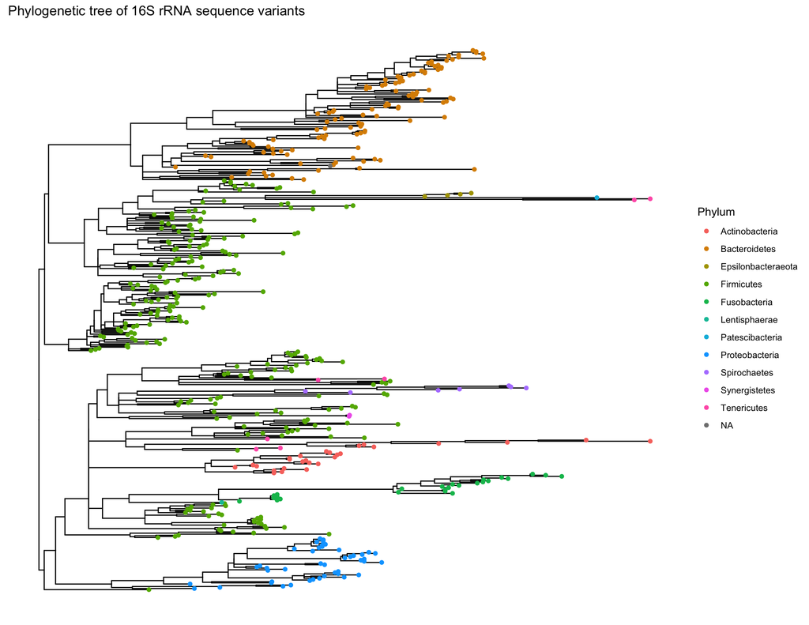

```r
ggtree(tree) %<+% taxonomy +
  geom_tippoint(aes(color=Phylum)) +
  theme(legend.position="right") +
  ggtitle("Phylogenetic tree of 16S rRNA sequence variants")
```

**QUESTION: Examine the phylogenetic tree, do the locations and clustering of the phyla look correct to you?**

## 4.4 Cleaning up

It is always a good idea to remove the extra objects you no longer need. In our case we only need our metadata, table of SVs, taxonomy, and tree to go forward. The function below will remove everything but these variables. We will also remove our filtered reads as they will take up storage and not be of any further use.

```r
rm(list=setdiff(ls(), c("taxonomy","SVtable","metadata","tree")))
unlink("filtered_reads/", recursive=TRUE)
```

## 4.5 Plan B

If for some reason you have been unable to generate the analysis from above, you can download a copy of my session which contains everything you will need to proceed.

```r
download.file("https://github.com/jbisanz/BMS270_SP2019/raw/master/outputs/Processed.Rdata", "outputs/Processed.Rdata")
load("outputs/Processed.Rdata")
```

# 5 Visualizing Community Composition

## 5.1 Ordination

As discussed in your previous metagenomics tutorial, ordination approaches are commonly used to visualize community similarity between samples. There are multiple methods of measuring the distances between community compositions and multiple ways to ordinate them into visual space. Today we will only use Principal Coordinate Analysis (PCoA), but we will use three distance/dissimilarity metrics:

- [Bray Curtis](https://en.wikipedia.org/wiki/Bray%E2%80%93Curtis_dissimilarity) Considers the abundances of every SV.
- [Weighted UniFrac](https://en.wikipedia.org/wiki/UniFrac) Considers the abundance of every SV but also the phylogenetic relationship between them.
- [Aitchinson distance](https://www.ncbi.nlm.nih.gov/pmc/articles/PMC5695134/) A newer method which considers that data is compositional and applies a centered log ratio transformation to account for this. Then standard Euclidean distance can be calculated.

```r
SVtable_subsampled<-t(SVtable) %>% rrarefy(sample=min(colSums(SVtable))) %>% t() %>% apply(., 2,  function(x) x/sum(x))
SVtable_CLR<-apply(log2(SVtable+0.5), 2, function(x) x-mean(x))

distances<-list()
distances$braycurtis<-t(SVtable_subsampled) %>% vegdist(method="bray")
distances$unifrac<-UniFrac(phyloseq(otu_table(SVtable_subsampled, taxa_are_rows = T), tree), weighted=TRUE)
distances$aitchison<-t(SVtable_CLR) %>% dist(method="euclidian")

distances$unifrac
```

```
##                    Sample_1.fastq.gz Sample_10.fastq.gz Sample_11.fastq.gz
## Sample_10.fastq.gz        0.21689069
## Sample_11.fastq.gz        0.79692735         0.82668435
## Sample_12.fastq.gz        0.88837813         0.92021478         0.29272933
## Sample_13.fastq.gz        0.80773984         0.81563732         0.57652834
## Sample_14.fastq.gz        0.96243057         0.97609141         0.72584531
## Sample_15.fastq.gz        0.48576827         0.48478663         0.70322034
## Sample_16.fastq.gz        0.77782719         0.80386575         0.20727946
## Sample_17.fastq.gz        0.70495082         0.74235995         0.31026554
## Sample_18.fastq.gz        0.70599467         0.74337251         0.19085260
## Sample_19.fastq.gz        0.25552973         0.20186734         0.78818206
## Sample_2.fastq.gz         0.55570487         0.57548772         0.65363534
## Sample_20.fastq.gz        0.50298501         0.48948203         0.69122100
## Sample_21.fastq.gz        0.95873265         0.95701283         0.59716059
## Sample_22.fastq.gz        0.83403412         0.86642432         0.25912104
## Sample_23.fastq.gz        0.62573228         0.65709409         0.34739796
## Sample_24.fastq.gz        0.28523742         0.30379737         0.71986148
## Sample_25.fastq.gz        0.21589147         0.30770158         0.75502836
## Sample_26.fastq.gz        0.96925590         0.97619781         0.73488983
## Sample_27.fastq.gz        0.97236147         0.97895441         0.77479146
## Sample_3.fastq.gz         0.93329248         0.95544720         0.70363588
## Sample_4.fastq.gz         0.96742576         0.96468074         0.69528840
## Sample_5.fastq.gz         0.60507119         0.63689660         0.33914926
## Sample_6.fastq.gz         0.75987154         0.79598298         0.28939607
## Sample_7.fastq.gz         0.35428368         0.37892542         0.69547543
## Sample_9.fastq.gz         0.19653198         0.29996394         0.82946306
##                    Sample_12.fastq.gz Sample_13.fastq.gz
## Sample_10.fastq.gz
## Sample_11.fastq.gz
## Sample_12.fastq.gz
## Sample_13.fastq.gz         0.66329994
## Sample_14.fastq.gz         0.73022718         0.53761815
## Sample_15.fastq.gz         0.77923939         0.56976224
## Sample_16.fastq.gz         0.25853243         0.63761600
## Sample_17.fastq.gz         0.50898358         0.48029554
## Sample_18.fastq.gz         0.32581244         0.55250535
## Sample_19.fastq.gz         0.88592249         0.80115246
## Sample_2.fastq.gz          0.69309871         0.69914823
## Sample_20.fastq.gz         0.67429367         0.79972645
## Sample_21.fastq.gz         0.67757016         0.33947542
```

[output cut: 231 more lines]

```
## Sample_2.fastq.gz
## Sample_20.fastq.gz
## Sample_21.fastq.gz
## Sample_22.fastq.gz
## Sample_23.fastq.gz
## Sample_24.fastq.gz
## Sample_25.fastq.gz
## Sample_26.fastq.gz
## Sample_27.fastq.gz
## Sample_3.fastq.gz
## Sample_4.fastq.gz
## Sample_5.fastq.gz
## Sample_6.fastq.gz
## Sample_7.fastq.gz
## Sample_9.fastq.gz         0.44063594
```

As seen above, we now have all distance measurements between every set of samples. We can now ordinate them using pcoa. Because we have stored our distance matrices in a list, we can use the `lapply()` function to do the same function over all of them.

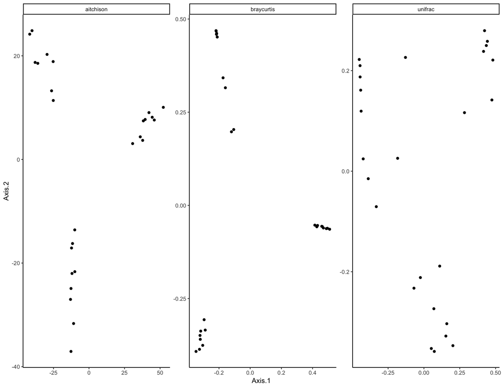

```r
pcoas<-lapply(distances, ape::pcoa)

lapply(names(pcoas), function(m){
  pcoas[[m]]$vectors %>% # the vectors slot contains the X/Y coordinates for plotting
    as.data.frame() %>%
    rownames_to_column("SampleID") %>%
    as_tibble() %>%
    mutate(Metric=m) %>%
    select(Metric, SampleID, Axis.1, Axis.2)
}) %>%
  do.call(bind_rows, .) %>%
  ggplot(aes(x=Axis.1, y=Axis.2, label=SampleID)) +
  geom_point() +
  facet_wrap(~Metric, scales="free") + # make one plot per metric
  theme_classic()
```

```r
ggsave("figures/OrdinationPlots.pdf", device="pdf", height=3, width=7, useDingbats=F)
```

**QUESTION:What do you observe based on these profiles? Do you have an intuition for how many biological groups may be present in this data? Why do these plots look different?**

It is also important to present the variation explained on each axis. We can extract this information from the individual ordinations as follows:

```r
lapply(names(pcoas), function(m){
  pcoas[[m]]$values %>%
  mutate(Metric=m) %>%
  mutate(PC=1:nrow(.)) %>%
  mutate(Percent_Variation_Explained=100*Relative_eig) %>%
  select(Metric, PC, Percent_Variation_Explained) %>%
  filter(PC<=2)
}) %>%
  do.call(bind_rows, .)
```

```
##       Metric PC Percent_Variation_Explained
## 1 braycurtis  1                    29.89373
## 2 braycurtis  2                    23.72162
## 3    unifrac  1                    49.39060
## 4    unifrac  2                    23.30233
## 5  aitchison  1                    38.25900
## 6  aitchison  2                    13.30782
```

**QUESTION:Which ordination captured the most variation explained?**

## 5.2 Clustering analysis

It would appear that there are discrete groups, irrespective of distance metric used, but to avoid arbitrarily identifying them, there are a number of clustering algorithms we could use. Today we will use [Partitioning Aound Medioids](https://en.wikipedia.org/wiki/K-medoids) (PAM) clustering. To determine the optimal number of clusters, we can use the [gap statistic](https://statweb.stanford.edu/~gwalther/gap). Our goal is to maximize the gap statistic in the minimal number of clusters.

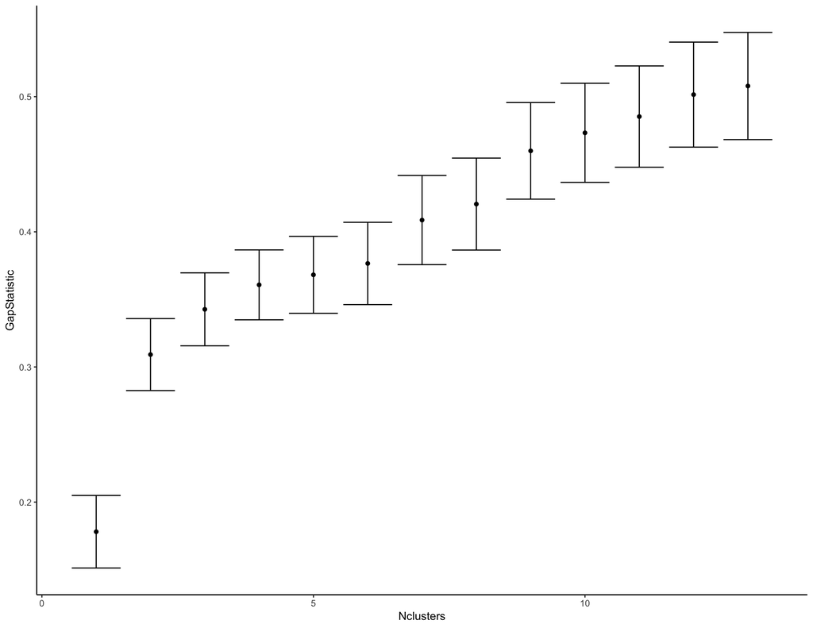

```r
do_pam<-function(distmat, Nclusters){list(cluster = pam(distmat,Nclusters, cluster.only=TRUE))}
gapstats<-clusGap(pcoas$aitchison$vectors, FUN=do_pam, K.max = 13, B=100) #maximum of 13 clusters (ie 2 per cluster)

gapstats<-
  gapstats$Tab %>%
  as.data.frame() %>%
  mutate(Nclusters=1:nrow(.)) %>%
  select(Nclusters, GapStatistic=gap, SE=SE.sim)

ggplot(gapstats, aes(x=Nclusters, y=GapStatistic, ymin=GapStatistic-SE, ymax=GapStatistic+SE)) +
  geom_errorbar() +
  geom_point() +
  theme_classic()
```

```r
ggsave("figures/gapstats.pdf", height=4, width=6, device="pdf", useDingbats=F)
```

**QUESTION:What do you think the optimal number of clusters is? Are there multple acceptable answers to this question?**

I am going to pick 3 clusters going forward.

```r
clusters<-pam(distances$braycurtis, k=3, diss=TRUE, cluster.only = TRUE)
clustered_metadata<-tibble(SampleID=names(clusters), Cluster=paste0("Cluster_", clusters))
```

Now we can replot our Aitchinson PCoA with the clusters. We can set the color to the cluster we identified above.

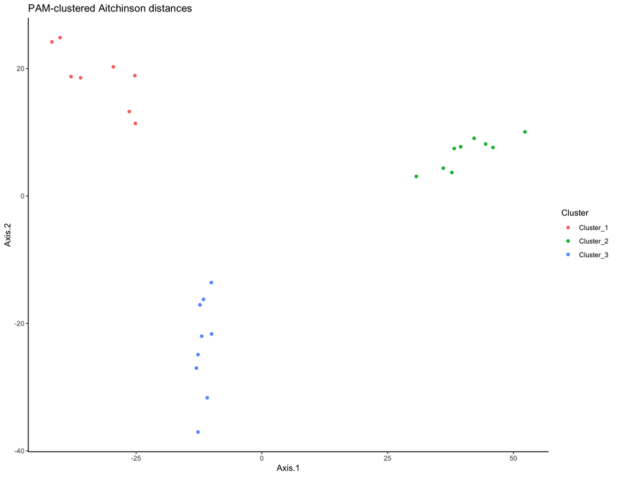

```r
pcoas$aitchison$vectors %>%
    as.data.frame() %>%
    rownames_to_column("SampleID") %>%
    select(SampleID, Axis.1, Axis.2) %>%
    left_join(clustered_metadata) %>%
  ggplot(aes(x=Axis.1, y=Axis.2, label=SampleID, color=Cluster)) +
  geom_point() +
  theme_classic() +
  ggtitle("PAM-clustered Aitchinson distances")
```

```r
ggsave("figures/PAM_clustered.pdf", height=4, width=6, device="pdf", useDingbats=F)
```

The next portions of our analysis will aim to uncover the nature of these clusters using commonly applied approaches.

## 5.3 Alpha Diversity Analysis

Alpha diversity is a measure of diversity within samples. Perhaps the simplest metric you could think of is the number of species present in an ecosystem which is commonly applied. Others try to estimate both the species you can see, and the ones you can’t, such as Chao1. Others are a little bit more complex such as Shannon Diversity which use both the number of species present and their abundances. Today we will use the number of observed SVs and the Shannon diversity.

**QUESTION: Which one of these metrics wil be most influenced by technical considerations?**

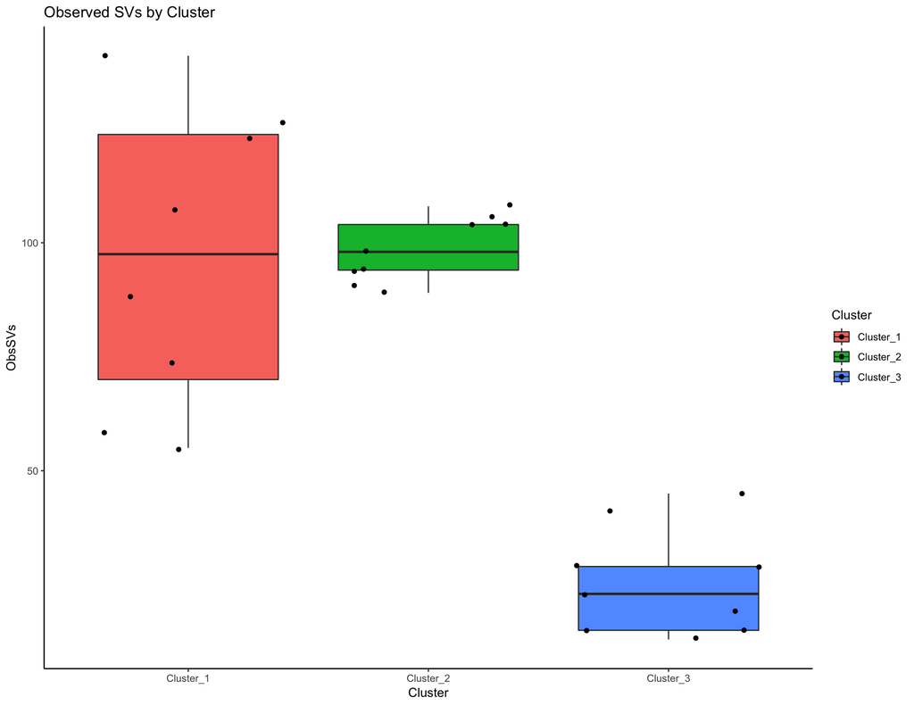

```r
ObsSVs<-specnumber(SVtable_subsampled, MARGIN=2)
  ObsSVs<-tibble(SampleID=names(ObsSVs), ObsSVs=ObsSVs)
Shannon_Diversity<-vegan::diversity(SVtable_subsampled, index="shannon", MARGIN=2)
  Shannon_Diversity<-tibble(SampleID=names(Shannon_Diversity), Shannon_Diversity=Shannon_Diversity)

clustered_metadata<-full_join(ObsSVs, Shannon_Diversity) %>% left_join(clustered_metadata)


ggplot(clustered_metadata, aes(x=Cluster, y=ObsSVs, fill=Cluster)) +
  geom_boxplot() +
  geom_jitter() +
  theme_classic() +
  ggtitle("Observed SVs by Cluster")
```

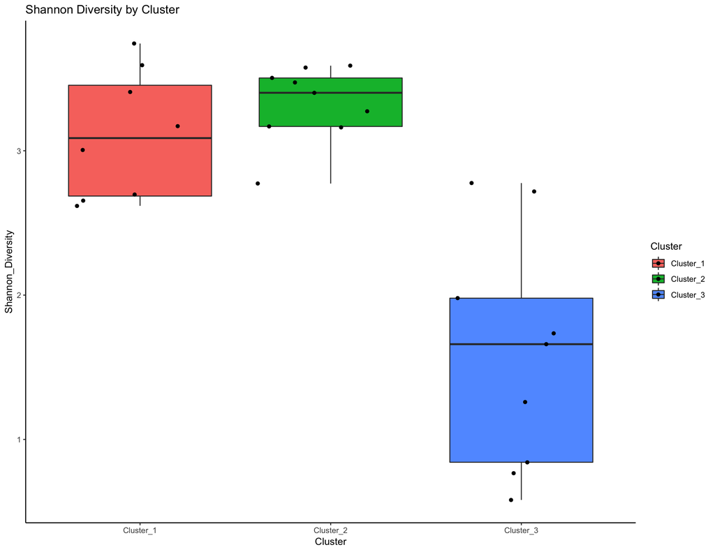

```r
ggsave("figures/ObsSVs.pdf", height=4, width=4, device="pdf", useDingbats=F)


ggplot(clustered_metadata, aes(x=Cluster, y=Shannon_Diversity, fill=Cluster)) +
  geom_boxplot() +
  geom_jitter() +
  theme_classic() +
  ggtitle("Shannon Diversity by Cluster")
```

```r
ggsave("figures/Shannon.pdf", height=4, width=4, device="pdf", useDingbats=F)
```

**QUESTION: Which one of these clusters is clearly an outlier from the other? What could this mean from a biological prospective?**

## 5.4 Taxonomic Barplot

A common way to look at the composition of samples is through a stacked bar plot. This generally involves calculating the percent abundances of higher level taxonomic assignments before plotting. We will do that below.

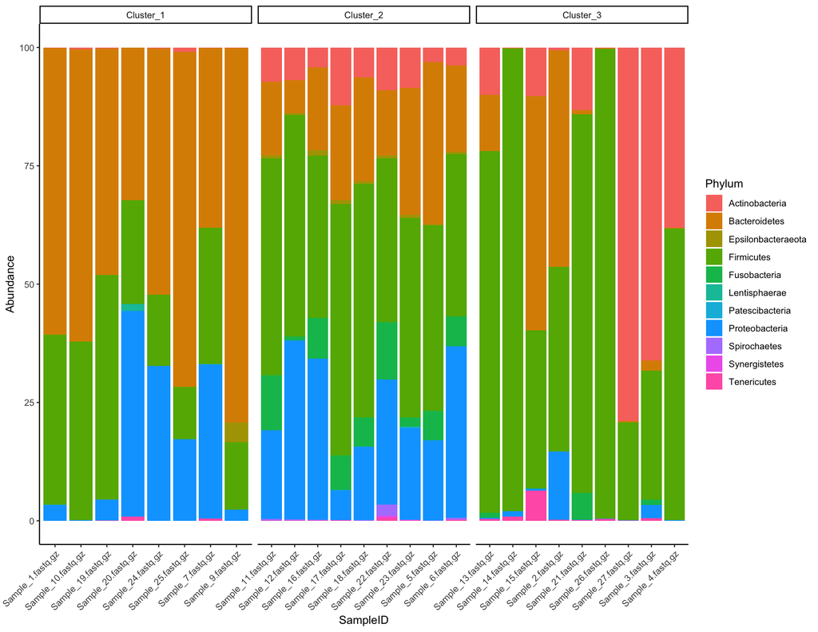

```r
SummedTaxa<-
  SVtable %>%
  apply(., 2, function(x) x/sum(x)*100) %>% #convert to percent
  as.data.frame() %>%
  rownames_to_column("SV") %>%
  as_tibble() %>%
  gather(-SV, key="SampleID", value="Abundance") %>% #reshape the table to plot
  left_join(taxonomy) %>%
  group_by(SampleID, Phylum) %>% #calculate the sum of abundance within eery pair of SampleID and Order
  summarize(Abundance=sum(Abundance))

SummedTaxa %>%
  left_join(clustered_metadata) %>%
  ggplot(aes(x=SampleID, y=Abundance, fill=Phylum)) +
  geom_bar(stat="identity") +
  theme(axis.text.x=element_text(angle=45, hjust=1)) +
  facet_wrap(~Cluster, scales="free_x") +
  theme_classic() +
  theme(axis.text.x=element_text(angle=45, hjust=1)) # rotate X axis text
```

```r
ggsave("figures/Phylum_barplots.pdf", height=4, width=7)
```

**QUESTION: What does this tell you about the taxonomic composition of these samples?**

**QUESTION: What happens if you make this plot as genus level instead of phylum?**

## 5.5 Heatmap

When many features are going to be plotted, heat maps can be a useful tool to aid in visualization, but any more than >50 taxa get too difficult to read. As such we will select the top 50 taxa to plot.

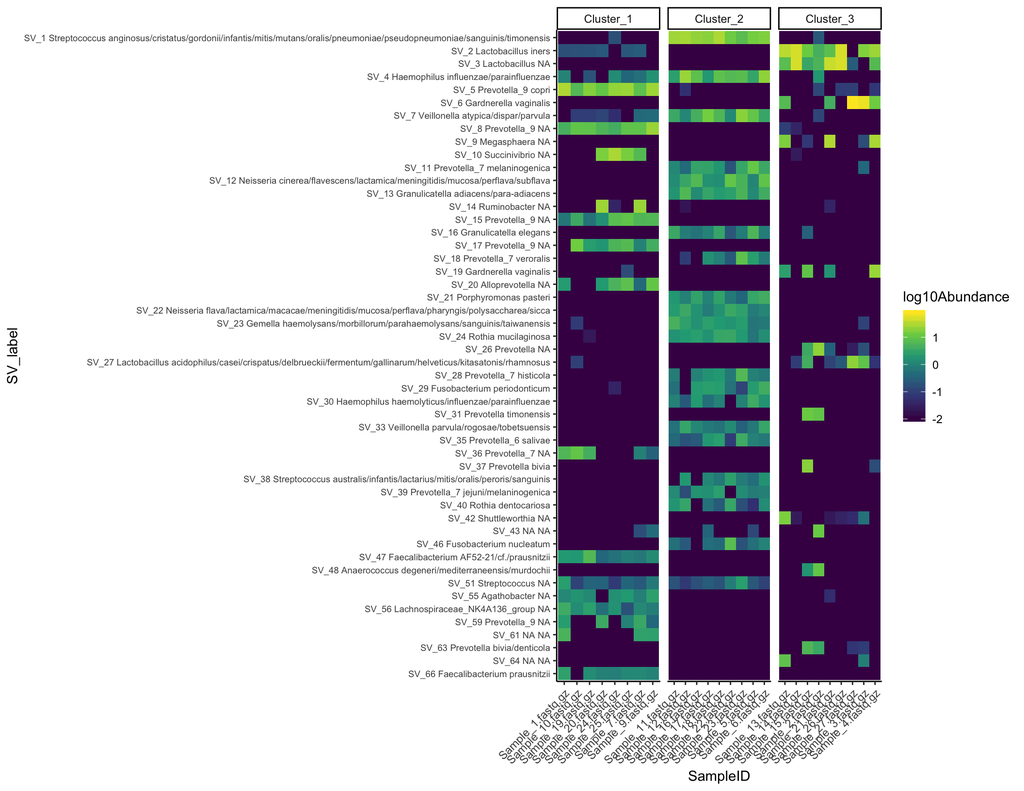

```r
SummedTaxa<-
  SVtable %>%
  apply(., 2, function(x) x/sum(x)*100) %>% #convert to percent
  as.data.frame() %>%
  rownames_to_column("SV") %>%
  as_tibble() %>%
  gather(-SV, key="SampleID", value="Abundance") %>% #reshape the table to plot
  left_join(taxonomy) %>%
  mutate(SV_label=paste(SV, Genus, Species)) # make a new label for the plot


MostAbundant<-SummedTaxa %>% group_by(SV_label) %>% summarize(mean=mean(Abundance)) %>% top_n(mean, n=50) %>% pull(SV_label)

SummedTaxa %>%
  filter(SV_label %in% MostAbundant) %>%
  mutate(log10Abundance=log10(Abundance+0.01)) %>%
  left_join(clustered_metadata) %>%
  mutate(SV_label=factor(SV_label, levels=rev(unique(SummedTaxa$SV_label)))) %>%
  ggplot(aes(x=SampleID, y=SV_label, fill=log10Abundance)) +
  geom_tile() +
  facet_wrap(~Cluster, scales="free_x") +
  scale_fill_viridis_c() +
  theme_classic() +
  theme(axis.text.y = element_text(size=7)) +
  theme(axis.text.x = element_text(angle=45, hjust=1))
```

```r
ggsave("figures/SV_heatmap.pdf", height = 7, width=12, device="pdf", useDingbats=F)
```

**QUESTION: What does this plot tell you about the taxonomic composition of these samples? What type of human samples do you think each of these clusters represents?**

**QUESTION: Does the taxonomic composition of these samples give you any indication of the geographic origin or diet of these individuals?**

# 6 Your Assignment

Your task is now to examine either cluster 1, 2, or cluster 3 in more detail. These samples represent multiple sampling of the same individuals over time: an obese pregnant women who gave birth by c-section, a healthy pregnant women who gives birth conventionally, and a undernourished women who gives birth conventionally. Using the methods we have covered thus far explore your cluster of choice, generate your hypothesis as to an aspect of the connection between the samples and prepare at least one figure to provide supporting evidence.

To get you started, you can use the following method to create a version of your table restricted to one cluster:

```r
cluster2_metadata<-clustered_metadata %>% filter(Cluster=="Cluster_2")
cluster2_SVtable<-SVtable_CLR[,cluster2_metadata$SampleID]
```

When you are done, share your findings with me and I will provide the key to the identities of the samples.